# Predicting and Analyzing U.S. Flight Delays: Identifying Key Factors and Improving Forecast Accuracy

Team 2 - JamesRiverhouse

2024-11-04

```r
library(dplyr)
library(ggplot2)
library(tidyr)
library(lubridate)
library(corrplot)
library(scales)
library(gridExtra)
library(stats)
library(reshape2)
```

# 1. Loading the Dataset

```r
flight <- data.frame(read.csv("Flight_delay.csv"))
str(flight)
```

```
## 'data.frame':    484551 obs. of  29 variables:
##  $ DayOfWeek        : int  4 4 4 4 4 4 4 4 4 4 ...
##  $ Date             : chr  "03-01-2019" "03-01-2019" "03-01-2019" "03-01-2019" ...
##  $ DepTime          : int  1829 1937 1644 1452 1323 1416 1657 1422 2107 1812 ...
##  $ ArrTime          : int  1959 2037 1845 1640 1526 1512 1754 1657 2334 1927 ...
##  $ CRSArrTime       : int  1925 1940 1725 1625 1510 1435 1735 1610 2230 1815 ...
##  $ UniqueCarrier    : chr  "WN" "WN" "WN" "WN" ...
##  $ Airline          : chr  "Southwest Airlines Co." "Southwest Airlines Co." "Southwest Airlines Co." "Southwest Airlines Co." ...
##  $ FlightNum        : int  3920 509 1333 675 4 54 623 188 362 422 ...
##  $ TailNum          : chr  "N464WN" "N763SW" "N334SW" "N286WN" ...
##  $ ActualElapsedTime: int  90 240 121 228 123 56 57 155 147 135 ...
##  $ CRSElapsedTime   : int  90 250 135 240 135 70 70 195 165 145 ...
##  $ AirTime          : int  77 230 107 213 110 49 47 143 134 118 ...
##  $ ArrDelay         : int  34 57 80 15 16 37 19 47 64 72 ...
##  $ DepDelay         : int  34 67 94 27 28 51 32 87 82 82 ...
##  $ Origin           : chr  "IND" "IND" "IND" "IND" ...
##  $ Org_Airport      : chr  "Indianapolis International Airport" "Indianapolis International Airport" "Indianapolis International Airport" "Indianapolis International Airport" ...
##  $ Dest             : chr  "BWI" "LAS" "MCO" "PHX" ...
##  $ Dest_Airport     : chr  "Baltimore-Washington International Airport" "McCarran International Airport" "Orlando International Airport" "Phoenix Sky Harbor International Airport" ...
##  $ Distance         : int  515 1591 828 1489 838 220 220 1093 972 765 ...
##  $ TaxiIn           : int  3 3 6 7 4 2 5 6 6 6 ...
##  $ TaxiOut          : int  10 7 8 8 9 5 5 6 7 11 ...
##  $ Cancelled        : int  0 0 0 0 0 0 0 0 0 0 ...
##  $ CancellationCode : chr  "N" "N" "N" "N" ...
##  $ Diverted         : int  0 0 0 0 0 0 0 0 0 0 ...
##  $ CarrierDelay     : int  2 10 8 3 0 12 7 40 5 3 ...
##  $ WeatherDelay     : int  0 0 0 0 0 0 0 0 0 0 ...
##  $ NASDelay         : int  0 0 0 0 0 0 0 0 0 0 ...
##  $ SecurityDelay    : int  0 0 0 0 0 0 0 0 0 0 ...
##  $ LateAircraftDelay: int  32 47 72 12 16 25 12 7 59 69 ...
```

Dataset loaded..

```r
column_names <- c('Day_of_Week','Date','Departure_Time','Arrival_Time','Scheduled_Arrival_Time',  'Unique_Carrier_Code','Carrier_name', 'Flight_Number','Tail_Number', 'Actual_Elapsed_Time_min','Estimated_Elapsed_Time_min','Air_Time_min', 'Arrival_Delay_min', 'Departure_Delay_min','Origin', 'Origin_Airport','Destination','Destination_Airport', 'Distance_mi','Taxi_In_min','Taxi_Out_min', 'Cancelled', 'CancellationCode','Diverted','Carrier_Delay_min','Weather_Delay_min', 'NAS_Delay_min','Security_Delay_min','Late_Aircraft_Delay_min')

colnames(flight) <- column_names
unique_carriers <- data.frame(unique(flight[,7]))
```

# 2. Data Cleaning & Summary of Dataset

Summary:

```r
summary(flight)
```

```
##   Day_of_Week       Date           Departure_Time  Arrival_Time
##  Min.   :1.00   Length:484551      Min.   :   1   Min.   :   1
##  1st Qu.:2.00   Class :character   1st Qu.:1234   1st Qu.:1327
##  Median :4.00   Mode  :character   Median :1620   Median :1737
##  Mean   :3.99                      Mean   :1564   Mean   :1618
##  3rd Qu.:6.00                      3rd Qu.:1928   3rd Qu.:2049
##  Max.   :7.00                      Max.   :2400   Max.   :2400
##  Scheduled_Arrival_Time Unique_Carrier_Code Carrier_name       Flight_Number
##  Min.   :   1           Length:484551       Length:484551      Min.   :   1
##  1st Qu.:1339           Class :character    Class :character   1st Qu.: 629
##  Median :1723           Mode  :character    Mode  :character   Median :1514
##  Mean   :1652                                                  Mean   :2139
##  3rd Qu.:2025                                                  3rd Qu.:3683
##  Max.   :2359                                                  Max.   :8403
##  Tail_Number        Actual_Elapsed_Time_min Estimated_Elapsed_Time_min
##  Length:484551      Min.   : 15             Min.   :-21
##  Class :character   1st Qu.: 80             1st Qu.: 79
##  Mode  :character   Median :116             Median :114
##                     Mean   :135             Mean   :131
##                     3rd Qu.:168             3rd Qu.:162
##                     Max.   :727             Max.   :602
##   Air_Time_min Arrival_Delay_min Departure_Delay_min    Origin
##  Min.   :  0   Min.   :  15      Min.   :   6        Length:484551
##  1st Qu.: 57   1st Qu.:  25      1st Qu.:  23        Class :character
##  Median : 90   Median :  42      Median :  40        Mode  :character
##  Mean   :109   Mean   :  61      Mean   :  57
##  3rd Qu.:139   3rd Qu.:  76      3rd Qu.:  72
##  Max.   :609   Max.   :1707      Max.   :1710
##  Origin_Airport     Destination        Destination_Airport  Distance_mi
##  Length:484551      Length:484551      Length:484551       Min.   :  31
##  Class :character   Class :character   Class :character    1st Qu.: 331
##  Mode  :character   Mode  :character   Mode  :character    Median : 599
##                                                            Mean   : 752
##                                                            3rd Qu.: 992
##                                                            Max.   :4502
##   Taxi_In_min     Taxi_Out_min   Cancelled CancellationCode      Diverted
##  Min.   :  0.0   Min.   :  0   Min.   :0   Length:484551      Min.   :0
##  1st Qu.:  4.0   1st Qu.: 11   1st Qu.:0   Class :character   1st Qu.:0
##  Median :  5.0   Median : 15   Median :0   Mode  :character   Median :0
##  Mean   :  6.8   Mean   : 19   Mean   :0                      Mean   :0
##  3rd Qu.:  8.0   3rd Qu.: 22   3rd Qu.:0                      3rd Qu.:0
##  Max.   :207.0   Max.   :383   Max.   :0                      Max.   :0
##  Carrier_Delay_min Weather_Delay_min NAS_Delay_min  Security_Delay_min
##  Min.   :   0      Min.   :   0      Min.   :   0   Min.   :  0
##  1st Qu.:   0      1st Qu.:   0      1st Qu.:   0   1st Qu.:  0
##  Median :   2      Median :   0      Median :   1   Median :  0
##  Mean   :  17      Mean   :   3      Mean   :  14   Mean   :  0
##  3rd Qu.:  19      3rd Qu.:   0      3rd Qu.:  13   3rd Qu.:  0
##  Max.   :1707      Max.   :1148      Max.   :1357   Max.   :392
##  Late_Aircraft_Delay_min
##  Min.   :   0
##  1st Qu.:   0
##  Median :  13
##  Mean   :  27
##  3rd Qu.:  36
##  Max.   :1254
```

Number of rows before Data pre-processing: 484551

The airlines considered for analysis are:

| unique.flight…7.. |
| --- |
| Southwest Airlines Co. |
| Skywest Airlines Inc. |
| United Air Lines Inc. |
| US Airways Inc. |
| Delta Air Lines Inc. |
| Atlantic Southeast Airlines |
| Frontier Airlines Inc. |
| Hawaiian Airlines Inc. |
| American Eagle Airlines Inc. |
| American Airlines Inc. |
| Alaska Airlines Inc. |
| JetBlue Airways |

Reasons for the delay:

1. CarrierDelay → Flight delay due to carrier(e.g. maintenance or crew problems, aircraft cleaning, fueling, etc), 0 = No, yes = (in minutes)
2. WeatherDelay → Flight delay due to weather, 0 = No, yes = (in minutes)
3. NASDelay → Flight delay by NSA(National Aviation System), 0 = No, yes = (in minutes)
4. SecurityDelay → Flight delay by security reason, 0 = No, yes = (in minutes)
5. LateAircraftDelay → Flight delay by Aircraft reason, 0 = No, yes = (in minutes)

# 3. Data Preprocessing

## 3.1 - Outliers and null value removal

```r
remove_outliers <- function(df, columns) {
    df_clean <- df

    for(column_name in columns) {
        # Get the specified column
        x <- df_clean[[column_name]]

        # Removing NA values
        valid_rows <- !is.na(x)
        x_clean <- x[valid_rows]

        # Calculating Q1, Q3, and IQR
        Q1 <- quantile(x_clean, 0.25)
        Q3 <- quantile(x_clean, 0.75)
        IQR <- Q3 - Q1

        # bounds for outlier removal
        lower_bound <- Q1 - 1.5 * IQR
        upper_bound <- Q3 + 1.5 * IQR

        # summary before removal
        cat("\nProcessing", column_name, ":\n")
        cat("Original rows:", sum(valid_rows), "\n")
        cat("Q1:", Q1, "Q3:", Q3, "IQR:", IQR, "\n")
        cat("Lower bound:", lower_bound, "Upper bound:", upper_bound, "\n")

        # Deleting outlier rows
        keep_rows <- x >= lower_bound & x <= upper_bound & valid_rows
        df_clean <- df_clean[keep_rows, ]

        # summary after removal
        cat("Rows after removal:", nrow(df_clean), "\n")
        cat("Outliers removed:", sum(valid_rows) - nrow(df_clean), "\n\n")
    }

    return(df_clean)
}
```

```r
library(ggplot2)
flight_b <- remove_outliers(flight,c('Arrival_Delay_min','Carrier_Delay_min','Weather_Delay_min','NAS_Delay_min','Security_Delay_min','Late_Aircraft_Delay_min'))
```

```
##
## Processing Arrival_Delay_min :
## Original rows: 484551
## Q1: 25 Q3: 76 IQR: 51
## Lower bound: -51.5 Upper bound: 152
## Rows after removal: 453175
## Outliers removed: 31376
##
##
## Processing Carrier_Delay_min :
## Original rows: 453175
## Q1: 0 Q3: 19 IQR: 19
## Lower bound: -28.5 Upper bound: 47.5
## Rows after removal: 412919
## Outliers removed: 40256
##
##
## Processing Weather_Delay_min :
## Original rows: 412919
## Q1: 0 Q3: 0 IQR: 0
## Lower bound: 0 Upper bound: 0
## Rows after removal: 383690
## Outliers removed: 29229
##
##
## Processing NAS_Delay_min :
## Original rows: 383690
## Q1: 0 Q3: 13 IQR: 13
## Lower bound: -19.5 Upper bound: 32.5
## Rows after removal: 342437
## Outliers removed: 41253
##
##
## Processing Security_Delay_min :
## Original rows: 342437
## Q1: 0 Q3: 0 IQR: 0
## Lower bound: 0 Upper bound: 0
## Rows after removal: 340348
## Outliers removed: 2089
##
##
## Processing Late_Aircraft_Delay_min :
## Original rows: 340348
## Q1: 0 Q3: 39 IQR: 39
## Lower bound: -58.5 Upper bound: 97.5
## Rows after removal: 325403
## Outliers removed: 14945
```

Number of rows after nulls and Outlier removal: 325403

## 3.2 - Normality checks

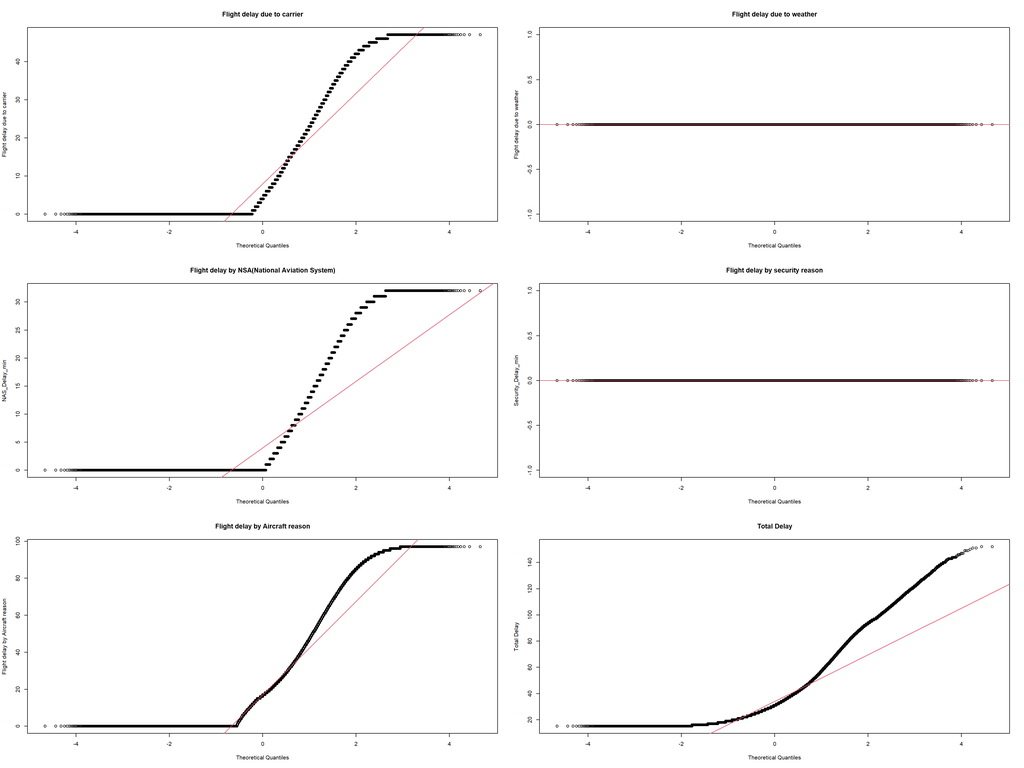

```r
par(mfrow = c(3, 2))
qqnorm(flight_b$Carrier_Delay_min, ylab = 'Flight delay due to carrier', main = "Flight delay due to carrier"); qqline(flight_b$Carrier_Delay_min,col=2)
qqnorm(flight_b$Weather_Delay_min, ylab = 'Flight delay due to weather', main = "Flight delay due to weather"); qqline(flight_b$Weather_Delay_min,col=2)
qqnorm(flight_b$NAS_Delay_min, ylab = 'NAS_Delay_min', main = "Flight delay by NSA(National Aviation System)"); qqline(flight_b$NAS_Delay_min,col=2)
qqnorm(flight_b$Security_Delay_min, ylab = 'Security_Delay_min', main = "Flight delay by security reason"); qqline(flight_b$Security_Delay_min,col=2)
qqnorm(flight_b$Late_Aircraft_Delay_min, ylab = 'Flight delay by Aircraft reason', main = "Flight delay by Aircraft reason"); qqline(flight_b$Late_Aircraft_Delay_min,col=2)
qqnorm(flight_b$Arrival_Delay_min, ylab = 'Total Delay' , main = "Total Delay"); qqline(flight_b$Arrival_Delay_min,col=2)
```

weather and security delays are rare in this dataset and when they occur, they’re likely significant outliers.

None of the delay types follow a normal distribution.

Since these distributions are not normal, Parametric statistical studies cannot be performed.

# 4. SMART Questions & EDA

# SMART Q1

“For top 5 most delayed airlines, can we identify major reasons and its trend over 6 months, so that it can help airlines to relocate proper resources and improve its operational efficiencies”

## 4.1 - Identifying top 5 airlines:

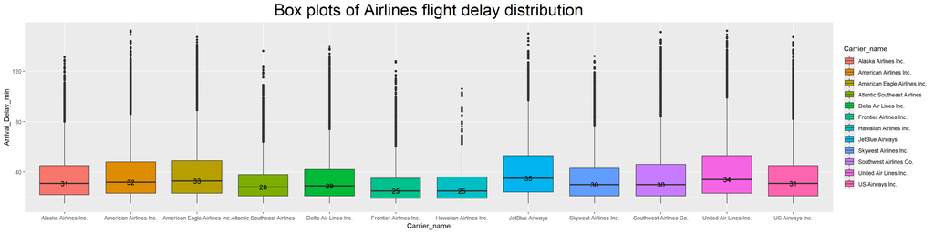

```r
ggplot(flight_b,aes(Carrier_name,Arrival_Delay_min))+geom_boxplot(aes(fill = Carrier_name ))+labs(title = "Box plots of Airlines flight delay distribution") + theme(plot.title = element_text(size = 25,hjust =0.5)) + stat_summary(aes(y = Arrival_Delay_min , label = round(..y.., 2)),
                 fun.y = median, geom = "text")
```

From the box-plots above, higher median lines are found for:

JetBlue Airways

United Air Lines Inc.

American Eagle Airlines Inc.

American Airlines Inc.

US Airways Inc.

```r
flight_5 <- flight_b[flight_b$Carrier_name %in% c('JetBlue Airways','United Air Lines Inc.','US Airways Inc.','American Airlines Inc.','American Eagle Airlines Inc.'),]
```

## 4.2 - Identifying major reasons for these 5 airlines:

```r
library(ggplot2)
library(reshape2)
avg_delays <- aggregate(
  cbind(
    Carrier_Delay_min,
    Weather_Delay_min,
    NAS_Delay_min,
    Security_Delay_min,
    Late_Aircraft_Delay_min
  ) ~ Carrier_name,
  data = flight_5,
  FUN = mean,
  na.rm = TRUE
)

delay_long <- melt(
  avg_delays,
  id.vars = "Carrier_name"
)

delay_long <- melt(avg_delays, id.vars = "Carrier_name")
delay_totals <- aggregate(value ~ Carrier_name, data = delay_long, sum)
delay_long <- merge(delay_long, delay_totals, by = "Carrier_name",
                   suffixes = c("", "_total"))
delay_long$percentage <- (delay_long$value / delay_long$value_total)*100

threshold <- 0
delay_long$label <- ifelse(delay_long$percentage >  threshold, sprintf("%.1f%%",delay_long$percentage),"")
```

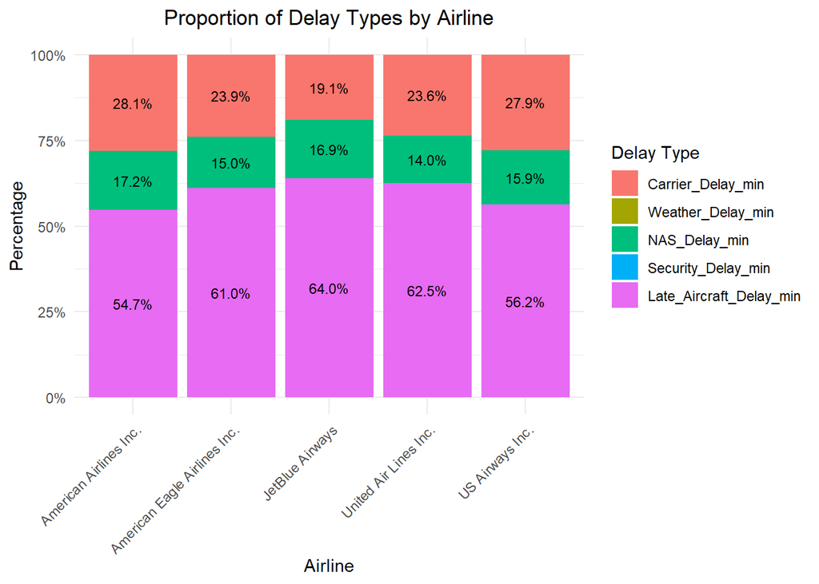

```r
ggplot(delay_long, aes(x = Carrier_name, y = value, fill = variable)) +
  geom_bar(stat = "identity", position = "fill") +
  geom_text(aes(label = label),
            position = position_fill(vjust = 0.5),size = 3)+
  theme_minimal() +
  labs(
    title = "Proportion of Delay Types by Airline",
    x = "Airline",
    y = "Percentage",
    fill = "Delay Type"
  ) +
  theme(
    axis.text.x = element_text(angle = 45, hjust = 1),
    plot.title = element_text(hjust = 0.5)
  ) +
  scale_y_continuous(labels = scales::percent)
```

```r
flight_5$MonthYear <- format(as.Date(flight_5$Date, "%d-%m-%Y"), "%b-%Y")

# Calculate monthly averages for each airline and delay type
monthly_delays <- aggregate(
  cbind(
    Carrier_Delay_min,
    Weather_Delay_min,
    NAS_Delay_min,
    Security_Delay_min,
    Late_Aircraft_Delay_min
  ) ~ MonthYear + Carrier_name,
  data = flight_5,
  FUN = mean,
 na.rm = TRUE
)
```

```r
delay_long <- melt(monthly_delays,
                  id.vars = c("MonthYear", "Carrier_name"),
                  variable.name = "Delay_Type",
                  value.name="Minutes")
```

Analysis from above graph:

1. Late Aircraft Delay dominates across all airlines, accounting for the largest proportion of delays, highest being in JetBlue Airways (64.0%).
2. Followed by Carrier Delay and NAS Delay, all three combined causes 100% delays.
3. Weather and Security delays appear minimal or non-existent
4. Late aircraft delays being dominant suggests a huge impact in airline operations
5. Different airlines might need different strategies based on their delay profiles, for example JetBlue might focus on late aircraft issues, while American Airlines might prioritize carrier-related delays since American Airlines has the highest percentage compared to others.

## 4.3 - Identifying major reasons for these 5 airlines:

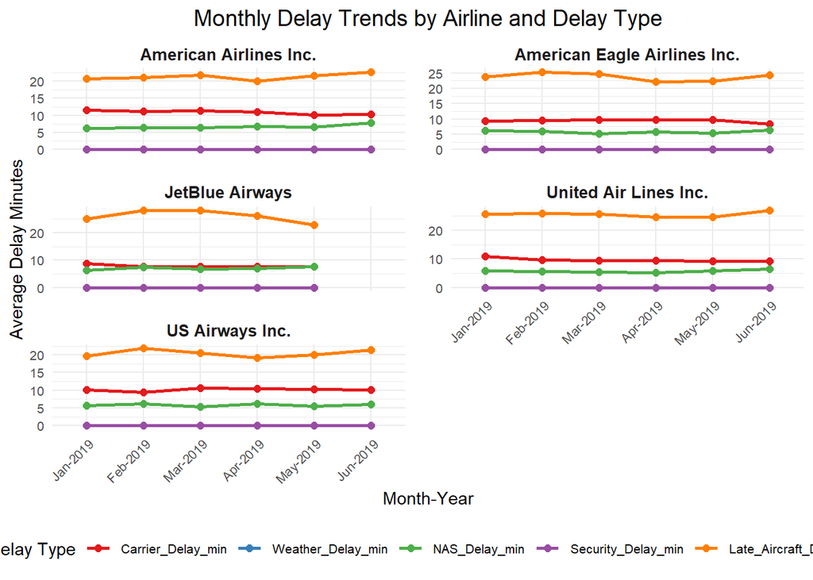

```r
library(dplyr)

delay_long <- delay_long %>%
  mutate(
    MonthDate = as.Date(paste0("01-", MonthYear), format = "%d-%b-%Y"),
    MonthYear = factor(format(MonthDate, "%b-%Y"),levels = format(sort(unique(MonthDate)),"%b-%Y")))
ggplot(delay_long,
       aes(x = MonthYear,
           y = Minutes,
           color = Delay_Type,
           group = Delay_Type)) +
  geom_line(linewidth = 1) +
  geom_point(size = 2) +
  facet_wrap(~Carrier_name, ncol = 2, scales = "free_y") +
  theme_minimal() +
  labs(
    title = "Monthly Delay Trends by Airline and Delay Type",
    x = "Month-Year",
    y = "Average Delay Minutes",
    color = "Delay Type"
  ) +
  theme(
    axis.text.x = element_text(angle = 45, hjust = 1, size = 8),
    axis.text.y = element_text(size = 8),
    strip.text = element_text(size = 10, face = "bold"),
    plot.title = element_text(size = 14, hjust = 0.5),
    legend.position = "bottom",
    legend.text = element_text(size = 8),
    panel.spacing = unit(1, "lines")
  ) +
  scale_color_brewer(palette = "Set1") +
  guides(color = guide_legend(nrow=1))
```

Consistency of analysis over 6 month period:

1. Late Aircraft Delays (orange line) consistently show the highest delays across all airlines
2. Security Delays (purple line) consistently show the lowest delays
3. Most trends remain relatively stable across the 6-month period

# SMART Q2

“Which U.S. airports consistently experience the highest cumulative delays across different delay causes (Carrier, Weather, NAS, Security, Late Aircraft) for both origin and destination flights, and how does this ranking vary on a monthly or seasonal basis over the observed period?”

```r
# Filtering Data
flight_data <- flight_b %>%
  filter(!is.na(Carrier_Delay_min) | !is.na(Weather_Delay_min) |
         !is.na( NAS_Delay_min) | !is.na(Security_Delay_min) |
         !is.na(Late_Aircraft_Delay_min))
```

```r
# Formatting Date and adding Month and Season column
flight_data$Date <- as.Date(flight_data$Date, format = "%d-%m-%Y")
flight_data_cleaned <- flight_data %>%
  mutate(Month = month(Date, label = TRUE, abbr = TRUE),
         Season = case_when(
           Month %in% c("Dec", "Jan", "Feb") ~ "Winter",
           Month %in% c("Mar", "Apr", "May") ~ "Spring",
           Month %in% c("Jun", "Jul", "Aug") ~ "Summer",
           Month %in% c("Sep", "Oct", "Nov") ~ "Fall"
         ))
```

```r
# Cleaning Dataframe
flight_delays <- flight_data_cleaned %>%
  filter(!is.na(Carrier_Delay_min) | !is.na(Weather_Delay_min) |
         !is.na( NAS_Delay_min) | !is.na(Security_Delay_min) |
         !is.na(Late_Aircraft_Delay_min)) %>%
  select(Origin, Destination, Carrier_Delay_min, Weather_Delay_min,  NAS_Delay_min, Security_Delay_min, Late_Aircraft_Delay_min, Month, Season)
```

```r
# Checking NA count
na_count <- colSums(is.na(flight_delays))
#print(na_count)
```

```r
#head(flight_delays)
```

```r
### Checking all the rows if delay exists or not
flight_delays$outcome <- ifelse(rowSums(flight_delays == 0) == ncol(flight_delays), 1, 0)
no_delay_rows <- flight_delays[flight_delays$outcome == 1, ]
#head(no_delay_rows)
```

## 4.4 - Frequency of top 10 Origin and Destination airports delay

To identify the airports with the highest delay frequency, we aggregated the data by origin and destination airports and calculated the total count of delays for each. Using the ggplot2 library, a bar chart was created to visualize these counts, with separate bars for origin and destination delays.

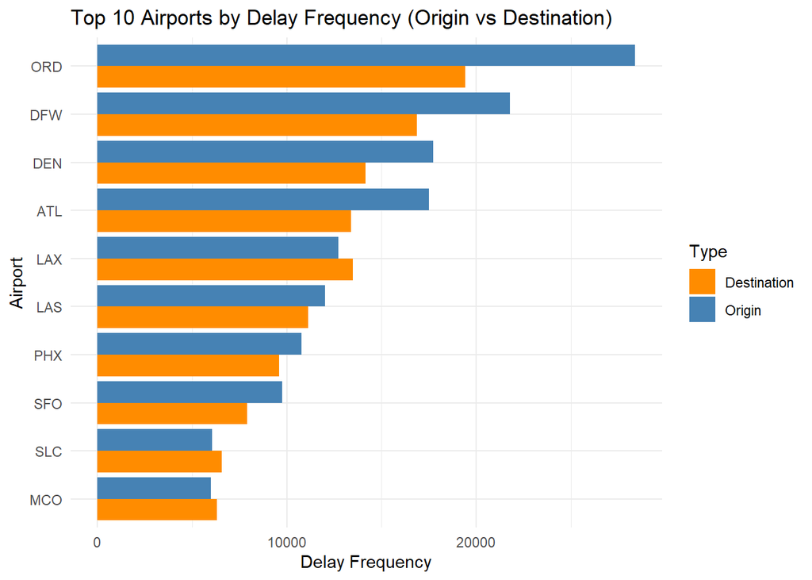

```r
origin_counts <- flight_delays %>%
  group_by(Origin) %>%
  summarise(Frequency = n()) %>%
  arrange(desc(Frequency)) %>%
  mutate(Type = "Origin")

Destination_counts <- flight_delays %>%
  group_by(Destination) %>%
  summarise(Frequency = n()) %>%
  arrange(desc(Frequency)) %>%
  mutate(Type = "Destination")

origin_counts <- rename(origin_counts, Airport = Origin)
Destination_counts <- rename(Destination_counts, Airport = Destination)

combined_counts <- bind_rows(origin_counts, Destination_counts)

top_airports <- combined_counts %>%
  group_by(Airport) %>%
  summarise(TotalFrequency = sum(Frequency)) %>%
  arrange(desc(TotalFrequency)) %>%
  slice(1:10)

final_counts <- combined_counts %>%
  filter(Airport %in% top_airports$Airport)

ggplot(final_counts, aes(x = reorder(Airport, Frequency), y = Frequency, fill = Type)) +
  geom_bar(stat = "identity", position = "dodge") +
  labs(title = "Top 10 Airports by Delay Frequency (Origin vs Destination)",
       x = "Airport", y = "Delay Frequency") +
  theme_minimal() +
  coord_flip() +
  scale_fill_manual(values = c("Origin" = "steelblue", "Destination" = "darkorange"))
```

To explore which specific delay causes are most prevalent at the top 10 airports, a heatmap was generated. We first isolated the delay causes for each airport and then aggregated them to calculate the total delay minutes per cause for each airport. The causes included Carrier delays, Weather delays, NAS (National Airspace System) delays, Security delays, and Late Aircraft delays.

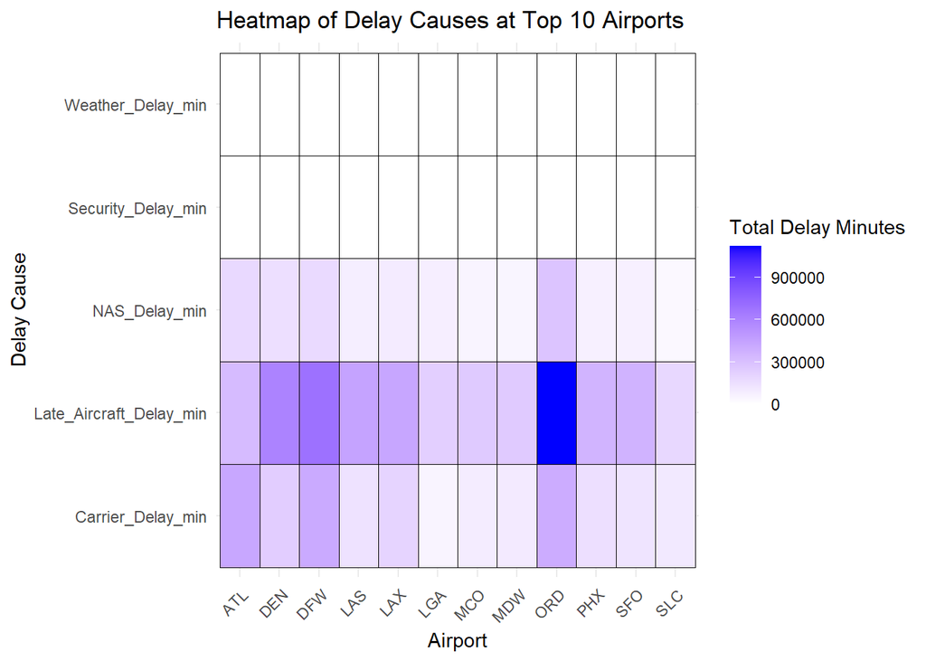

```r
top_origin_airports <- flight_delays %>%
  group_by(Origin) %>%
  summarize(TotalDelay = sum(Carrier_Delay_min, Weather_Delay_min,  NAS_Delay_min, Security_Delay_min, Late_Aircraft_Delay_min, na.rm = TRUE)) %>%
  arrange(desc(TotalDelay)) %>%
  slice_head(n = 10) %>%
  pull(Origin)

top_Destination_airports <- flight_delays %>%
  group_by(Destination) %>%
  summarize(TotalDelay = sum(Carrier_Delay_min, Weather_Delay_min,  NAS_Delay_min, Security_Delay_min, Late_Aircraft_Delay_min, na.rm = TRUE)) %>%
  arrange(desc(TotalDelay)) %>%
  slice_head(n = 10) %>%
  pull(Destination)

top_airports <- unique(c(top_origin_airports, top_Destination_airports))

filtered_delays <- flight_delays %>%
  filter(Origin %in% top_airports | Destination %in% top_airports)

heatmap_data <- filtered_delays %>%
  select(Origin, Destination, Carrier_Delay_min, Weather_Delay_min,  NAS_Delay_min, Security_Delay_min, Late_Aircraft_Delay_min) %>%
  pivot_longer(cols = c(Carrier_Delay_min, Weather_Delay_min,  NAS_Delay_min, Security_Delay_min, Late_Aircraft_Delay_min),
               names_to = "DelayType",
               values_to = "TotalDelay") %>%
  mutate(Airport = ifelse(Origin %in% top_airports, Origin, Destination)) %>%
  filter(!is.na(TotalDelay))

heatmap_summary <- heatmap_data %>%
  group_by(Airport, DelayType) %>%
  summarize(TotalDelay = sum(TotalDelay, na.rm = TRUE)) %>%
  ungroup()

ggplot(heatmap_summary, aes(x = Airport, y = DelayType, fill = TotalDelay)) +
  geom_tile(color = "black") +
  scale_fill_gradient(low = "white", high = "blue", na.value = "grey50") +
  labs(title = "Heatmap of Delay Causes at Top 10 Airports",
       x = "Airport",
       y = "Delay Cause",
       fill = "Total Delay Minutes") +
  theme_minimal() +
  theme(axis.text.x = element_text(angle = 45, hjust = 1))
```

```r
top_origin_airports <- flight_delays %>%
  group_by(Origin) %>%
  summarize(TotalDelay = sum(Carrier_Delay_min, Weather_Delay_min,  NAS_Delay_min, Security_Delay_min, Late_Aircraft_Delay_min, na.rm = TRUE)) %>%
  arrange(desc(TotalDelay)) %>%
  slice_head(n = 10) %>%
  pull(Origin)

top_Destination_airports <- flight_delays %>%
  group_by(Destination) %>%
  summarize(TotalDelay = sum(Carrier_Delay_min, Weather_Delay_min,  NAS_Delay_min, Security_Delay_min, Late_Aircraft_Delay_min, na.rm = TRUE)) %>%
  arrange(desc(TotalDelay)) %>%
  slice_head(n = 10) %>%
  pull(Destination)

top_airports <- unique(c(top_origin_airports, top_Destination_airports))

filtered_delays <- flight_delays %>%
  filter(Origin %in% top_airports | Destination %in% top_airports)

print(colnames(filtered_delays))
```

```
##  [1] "Origin"                  "Destination"
##  [3] "Carrier_Delay_min"       "Weather_Delay_min"
##  [5] "NAS_Delay_min"           "Security_Delay_min"
##  [7] "Late_Aircraft_Delay_min" "Month"
##  [9] "Season"                  "outcome"
```

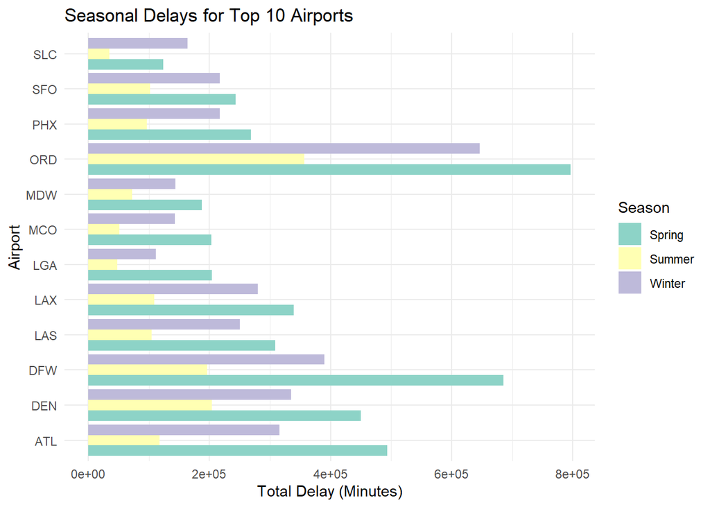

```r
seasonal_delays <- filtered_delays %>%
  select(Origin, Destination, Carrier_Delay_min, Weather_Delay_min,  NAS_Delay_min, Security_Delay_min, Late_Aircraft_Delay_min, Season) %>%

  pivot_longer(cols = c(Carrier_Delay_min, Weather_Delay_min,  NAS_Delay_min, Security_Delay_min, Late_Aircraft_Delay_min),
               names_to = "DelayType", values_to = "TotalDelay") %>%
  mutate(Airport = ifelse(Origin %in% top_airports, Origin, Destination)) %>%
  group_by(Airport, Season) %>%
  summarize(TotalDelay = sum(TotalDelay, na.rm = TRUE), .groups = 'drop')

ggplot(seasonal_delays, aes(x = Airport, y = TotalDelay, fill = Season)) +
  geom_bar(stat = "identity", position = "dodge") +
  labs(title = "Seasonal Delays for Top 10 Airports",
       x = "Airport", y = "Total Delay (Minutes)") +
  theme_minimal() +
  coord_flip() +
  scale_fill_brewer(palette = "Set3")
```

```r
flight_b$Date <- as.Date(flight_b$Date)
flight_b$Month <- month(flight_b$Date)
```

```r
# Filter summer months (June-August)
summer_data <- flight_b %>%filter(Month %in% c(6, 7, 8))
```

```r
## Calculate average delays by carrier
carrier_delays <- summer_data %>%
  group_by(Unique_Carrier_Code) %>%
  summarise(
    AvgArrival_Delay_min = mean(Arrival_Delay_min, na.rm = TRUE),
    AvgDeparture_Delay_min = mean(Departure_Delay_min, na.rm = TRUE),
    TotalDelay = AvgArrival_Delay_min + AvgDeparture_Delay_min,
    Carrier_Delay_min = mean(Carrier_Delay_min, na.rm = TRUE),
    Weather_Delay_min = mean(Weather_Delay_min, na.rm = TRUE)
  ) %>%
  arrange(desc(TotalDelay))

top_3_carriers <- head(carrier_delays, 3)
```

# SMART Q3

“What are the top 3 carriers with the highest average delay times during peak summer months (June-August), and how do their delay patterns correlate with specific routes and time of day?”

## 4.7 - Top 3 Carriers Average Delays

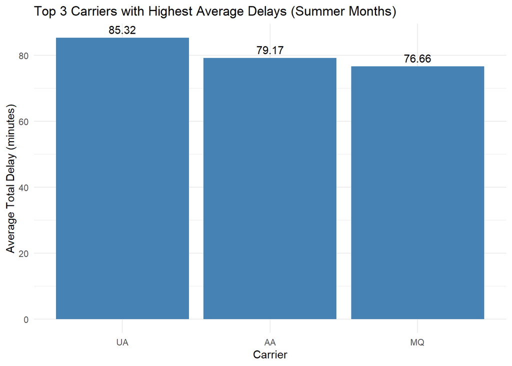

```r
ggplot(top_3_carriers, aes(x = reorder(Unique_Carrier_Code, -TotalDelay), y = TotalDelay)) +
  geom_bar(stat = "identity", fill = "steelblue") +
  geom_text(aes(label = round(TotalDelay, 2)), vjust = -0.5) +
  theme_minimal() +
  labs(
    title = "Top 3 Carriers with Highest Average Delays (Summer Months)",
    x = "Carrier",
    y = "Average Total Delay (minutes)"
  )
```

## Time of Day Analysis

```r
summer_data$Hour <- as.numeric(format(strptime(sprintf("%04d", summer_data$Departure_Time),format = "%H%M"), "%H"))
```

This result was based on the fact that people were traveling cross country to meet friends, family and also on holidays. This means the higher traffic was traveling to different parts of the country and such analysis helps airlines to work on making these routes more efficient and providing higher quality services here.

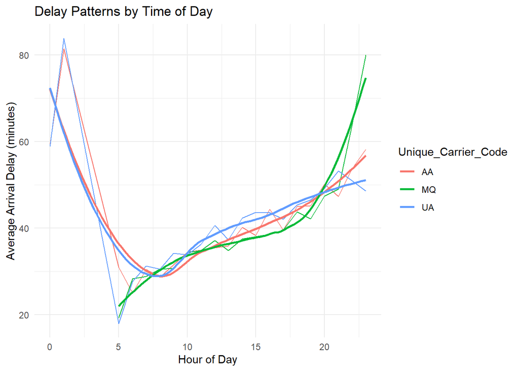

```r
# Visualization 2: Delay Patterns by Time of Day
hourly_delays <- summer_data %>%
  filter(Unique_Carrier_Code %in% top_3_carriers$Unique_Carrier_Code) %>%
  group_by(Unique_Carrier_Code, Hour) %>%
  summarise(AvgDelay = mean(Arrival_Delay_min, na.rm = TRUE))

ggplot(hourly_delays, aes(x = Hour, y = AvgDelay, color = Unique_Carrier_Code)) +
  geom_line() +
  geom_smooth(se = FALSE) +
  theme_minimal() +
  labs(
    title = "Delay Patterns by Time of Day",
    x = "Hour of Day",
    y = "Average Arrival Delay (minutes)"
  )
```

## Route Analysis

```r
route_delays <- summer_data %>%
  group_by(Unique_Carrier_Code, Origin, Destination) %>%
  summarise(
    AvgDelay = mean(Arrival_Delay_min, na.rm = TRUE),
    flight = n()
  ) %>%
  filter(flight >= 50) %>%  # Filter routes with minimum 50 flight
  arrange(desc(AvgDelay))
```

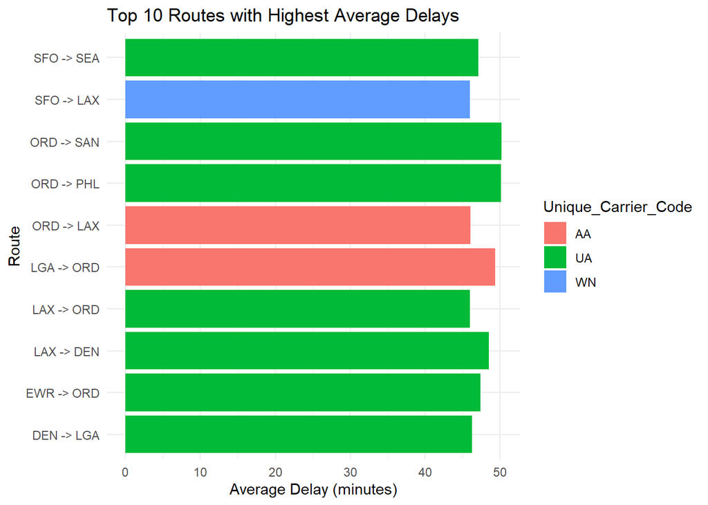

```r
top_10_routes <- head(route_delays, 10)
ggplot(top_10_routes,
       aes(x = paste(Origin, "->", Destination), y = AvgDelay, fill = Unique_Carrier_Code)) +
  geom_bar(stat = "identity") +
  coord_flip() +
  theme_minimal() +
  labs(
    title = "Top 10 Routes with Highest Average Delays",
    x = "Route",
    y = "Average Delay (minutes)"
  )
```

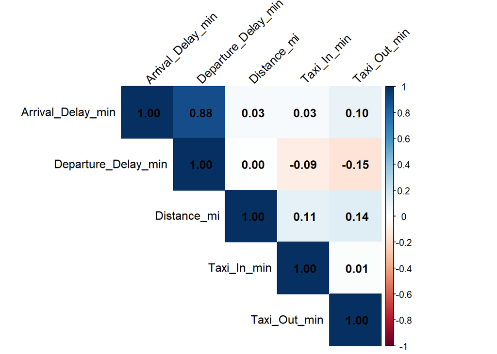

```r
# Correlation Analysis
library(corrplot)

correlation_vars <- summer_data %>%
  select(Arrival_Delay_min, Departure_Delay_min, Distance_mi, Taxi_In_min, Taxi_Out_min)
correlation_matrix <- cor(correlation_vars, use = "complete.obs")

# Visualization 4: Correlation Heatmap
corrplot(correlation_matrix,
         method = "color",
         type = "upper",
         addCoef.col = "black",
         tl.col = "black",
         tl.srt = 45)
```

```r
# Statistical Summary
summary_stats <- summer_data %>%
  group_by(Unique_Carrier_Code) %>%
  filter(Unique_Carrier_Code %in% top_3_carriers$Unique_Carrier_Code) %>%
  summarise(
    Mean_Delay = mean(Arrival_Delay_min, na.rm = TRUE),
    Median_Delay = median(Arrival_Delay_min, na.rm = TRUE),
    SD_Delay = sd(Arrival_Delay_min, na.rm = TRUE),
    Total_flight = n(),
    Delayed_flight = sum(Arrival_Delay_min > 0, na.rm = TRUE),
    Delay_Rate = Delayed_flight / Total_flight * 100
  )
print(summary_stats)
```

```
## # A tibble: 3 × 7
##   Unique_Carrier_Code Mean_Delay Median_Delay SD_Delay Total_flight
##   <chr>                    <dbl>        <dbl>    <dbl>        <int>
## 1 AA                        40.8           34     23.0         5317
## 2 MQ                        39.1           33     21.2         7314
## 3 UA                        42.7           36     24.3         7593
## # ℹ 2 more variables: Delayed_flight <int>, Delay_Rate <dbl>
```

```r
write.csv(summary_stats, "airline_delay_analysis.csv")
```

# SMART Q4

“What time of day do flights experience the highest frequency of delays? Are there specific hours when certain types of delays, such as (NAS, Security, or Late Aircraft) are more frequent?”

```r
# Data Preprocessing and Summary Statistics
# Convert time fields to proper format
flight_b$Departure_Time <- as.numeric(flight_b$Departure_Time)
flight_b$hour <- floor(flight_b$Departure_Time/100)

# Create binary delay indicator
flight_b$is_delayed <- ifelse(flight_b$Departure_Delay_min > 15, 1, 0)

# Basic summary statistics
summary(flight_b)
```

```
##   Day_of_Week        Date            Departure_Time  Arrival_Time
##  Min.   :1.00   Min.   :0001-01-20   Min.   :   1   Min.   :   1
##  1st Qu.:2.00   1st Qu.:0007-04-20   1st Qu.:1234   1st Qu.:1345
##  Median :4.00   Median :0015-04-20   Median :1612   Median :1737
##  Mean   :4.01   Mean   :0015-05-28   Mean   :1559   Mean   :1644
##  3rd Qu.:6.00   3rd Qu.:0023-01-20   3rd Qu.:1919   3rd Qu.:2045
##  Max.   :7.00   Max.   :0031-05-20   Max.   :2400   Max.   :2400
##  Scheduled_Arrival_Time Unique_Carrier_Code Carrier_name       Flight_Number
##  Min.   :   1           Length:325403       Length:325403      Min.   :   1
##  1st Qu.:1345           Class :character    Class :character   1st Qu.: 608
##  Median :1725           Mode  :character    Mode  :character   Median :1477
##  Mean   :1659                                                  Mean   :2047
##  3rd Qu.:2028                                                  3rd Qu.:3427
##  Max.   :2359                                                  Max.   :8403
##  Tail_Number        Actual_Elapsed_Time_min Estimated_Elapsed_Time_min
##  Length:325403      Min.   : 15             Min.   :-21
##  Class :character   1st Qu.: 77             1st Qu.: 75
##  Mode  :character   Median :110             Median :110
##                     Mean   :130             Mean   :129
##                     3rd Qu.:161             3rd Qu.:160
##                     Max.   :627             Max.   :602
##   Air_Time_min Arrival_Delay_min Departure_Delay_min    Origin
##  Min.   :  1   Min.   : 15.0     Min.   :  6.0       Length:325403
##  1st Qu.: 56   1st Qu.: 22.0     1st Qu.: 20.0       Class :character
##  Median : 87   Median : 31.0     Median : 32.0       Mode  :character
##  Mean   :107   Mean   : 37.2     Mean   : 36.9
##  3rd Qu.:137   3rd Qu.: 46.0     3rd Qu.: 48.0
##  Max.   :609   Max.   :152.0     Max.   :213.0
##  Origin_Airport     Destination        Destination_Airport  Distance_mi
##  Length:325403      Length:325403      Length:325403       Min.   :  31
##  Class :character   Class :character   Class :character    1st Qu.: 329
##  Mode  :character   Mode  :character   Mode  :character    Median : 590
##                                                            Mean   : 744
##                                                            3rd Qu.: 987
##                                                            Max.   :4502
##   Taxi_In_min    Taxi_Out_min     Cancelled CancellationCode      Diverted
##  Min.   : 0.0   Min.   :  0.0   Min.   :0   Length:325403      Min.   :0
##  1st Qu.: 4.0   1st Qu.: 10.0   1st Qu.:0   Class :character   1st Qu.:0
##  Median : 5.0   Median : 14.0   Median :0   Mode  :character   Median :0
##  Mean   : 6.4   Mean   : 16.4   Mean   :0                      Mean   :0
##  3rd Qu.: 7.0   3rd Qu.: 20.0   3rd Qu.:0                      3rd Qu.:0
##  Max.   :79.0   Max.   :148.0   Max.   :0                      Max.   :0
##  Carrier_Delay_min Weather_Delay_min NAS_Delay_min  Security_Delay_min
##  Min.   : 0.0      Min.   :0         Min.   : 0.0   Min.   :0
##  1st Qu.: 0.0      1st Qu.:0         1st Qu.: 0.0   1st Qu.:0
##  Median : 4.0      Median :0         Median : 0.0   Median :0
##  Mean   : 9.6      Mean   :0         Mean   : 5.1   Mean   :0
##  3rd Qu.:16.0      3rd Qu.:0         3rd Qu.: 8.0   3rd Qu.:0
##  Max.   :47.0      Max.   :0         Max.   :32.0   Max.   :0
##  Late_Aircraft_Delay_min     Month           hour        is_delayed
##  Min.   : 0.0            Min.   :1.00   Min.   : 0.0   Min.   :0.000
##  1st Qu.: 0.0            1st Qu.:2.00   1st Qu.:12.0   1st Qu.:1.000
##  Median :17.0            Median :3.00   Median :16.0   Median :1.000
##  Mean   :22.4            Mean   :3.39   Mean   :15.3   Mean   :0.848
##  3rd Qu.:34.0            3rd Qu.:5.00   3rd Qu.:19.0   3rd Qu.:1.000
##  Max.   :97.0            Max.   :6.00   Max.   :24.0   Max.   :1.000
```

```r
# Check for missing values
colSums(is.na(flight_b))
```

```
##                Day_of_Week                       Date
##                          0                          0
##             Departure_Time               Arrival_Time
##                          0                          0
##     Scheduled_Arrival_Time        Unique_Carrier_Code
##                          0                          0
##               Carrier_name              Flight_Number
##                          0                          0
##                Tail_Number    Actual_Elapsed_Time_min
##                          0                          0
## Estimated_Elapsed_Time_min               Air_Time_min
##                          0                          0
##          Arrival_Delay_min        Departure_Delay_min
##                          0                          0
##                     Origin             Origin_Airport
##                          0                          0
##                Destination        Destination_Airport
##                          0                          0
##                Distance_mi                Taxi_In_min
##                          0                          0
##               Taxi_Out_min                  Cancelled
##                          0                          0
##           CancellationCode                   Diverted
##                          0                          0
##          Carrier_Delay_min          Weather_Delay_min
##                          0                          0
##              NAS_Delay_min         Security_Delay_min
##                          0                          0
##    Late_Aircraft_Delay_min                      Month
##                          0                          0
##                       hour                 is_delayed
##                          0                          0
```

```r
# Descriptive Statistics
hourly_stats <- flight_b %>%
  group_by(hour) %>%
  summarise(
    total_flight = n(),
    delayed_flight = sum(is_delayed, na.rm = TRUE),
    delay_rate = delayed_flight/total_flight,
    avg_delay = mean(Departure_Delay_min, na.rm = TRUE),
    sd_delay = sd(Departure_Delay_min, na.rm = TRUE),
    carrier_delay = mean(Carrier_Delay_min, na.rm = TRUE),
    weather_delay = mean(Weather_Delay_min, na.rm = TRUE),
    nas_delay = mean( NAS_Delay_min, na.rm = TRUE),
    security_delay = mean(Security_Delay_min, na.rm = TRUE),
    late_aircraft_delay = mean(Late_Aircraft_Delay_min, na.rm = TRUE)
  )

print(hourly_stats)
```

```
## # A tibble: 25 × 11
##     hour total_flight delayed_flight delay_rate avg_delay sd_delay carrier_delay
##    <dbl>        <int>          <dbl>      <dbl>     <dbl>    <dbl>         <dbl>
##  1     0         1505           1347      0.895      47.4     28.3         11.6
##  2     1          457            436      0.954      59.0     29.2         10.3
##  3     2           90             86      0.956      58.4     33.6         10.3
##  4     3           17             16      0.941      47.1     21.2          8.88
##  5     4           29             28      0.966      49.8     23.5          2.21
##  6     5          147             69      0.469      21.8     18.6         15.4
##  7     6         3623           2183      0.603      20.9     11.5         18.2
##  8     7         6582           4481      0.681      24.2     13.4         18.5
##  9     8        10141           7124      0.702      25.2     14.6         15.1
## 10     9        11718           8895      0.759      28.6     17.3         12.7
## # ℹ 15 more rows
## # ℹ 4 more variables: weather_delay <dbl>, nas_delay <dbl>,
## #   security_delay <dbl>, late_aircraft_delay <dbl>
```

## 4.10 - Overall Delay pattern by hour

The bar chart depicts the pattern of hourly flight delays, which provides insight into the peak and low-delay periods and trends throughout the day. Evidently, the delays are at their highest during late-night hours between 12:00 AM and 3:00 AM and late evening between 6:00 PM and 11:00 PM. Lastly, there is a significant decrease in delay rates around 5:00 AM, which provides evidence that early morning is a time of lowest delays, possibly due to lower flight volumes or smoother operational efficiency in those hours. This low-delay period identifies the optimal window for on-time departures, possibly due to fewer inbound flight dependencies and favorable early-morning weather patterns.

The data shows that delay rates increase from about 6:00 AM and increase gradually throughout the day. The rate of delays rises in the afternoon and evening, peaking once more in late evening. This might indicate that compounding daily delays with increasing flight burden on airports, the weather effects, and possible network disruptions accumulate over time.

In a nutshell, these results underline the advantages of early morning flight schedules in reducing delay risks. The pattern also shows there is operational stress during late-night and evening hours, which could guide airlines and airports in resource allocation and improvements in the management of flight schedules to maintain smooth operations.

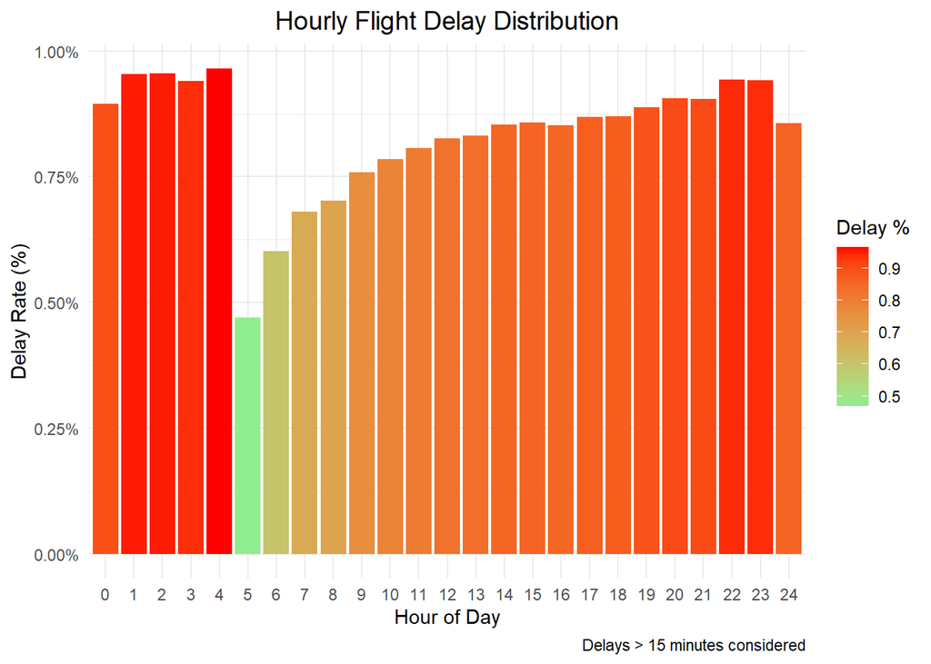

```r
ggplot(hourly_stats, aes(x = factor(hour), y = delay_rate, fill = delay_rate)) +
  geom_bar(stat = "identity") +
  scale_fill_gradient(low = "lightgreen", high = "red") +
  theme_minimal() +
  labs(title = "Hourly Flight Delay Distribution",
       x = "Hour of Day",
       y = "Delay Rate (%)",
       caption = "Delays > 15 minutes considered",
       fill = "Delay %") +
  theme(
    plot.title = element_text(hjust = 0.5, size = 14),
    axis.text.x = element_text(angle = 0),
    legend.position = "right"
  ) +
  scale_y_continuous(labels = scales::percent_format(scale = 1))
```

## 4.11 - Types of Delays by hour

This time series line graph helps analyze the trend of various delay types on an hourly basis and contributes toward identifying the main contributors to flight delays. The dataset classifies delay causes into five main types: Late Aircraft, Carrier, Weather, NAS (National Airspace System), and Security.

Insights for Operational Improvements - Identifying Late Aircraft as the top cause emphasizes the importance of smoothing out turnaround processes and scheduling flexibility, so minor delays can be absorbed without causing the next flights to be delayed. Carrier delays having a large effect indicates possible enhancements in operational management to decrease their rate of occurrence. Furthermore, a focused approach to deal with the problems related to weather, like better forecasting, could temper these effects, especially during peak travel times. This breakdown will provide a panoramic view of stakeholders meant to address and prioritize resources to specific causes of delay.

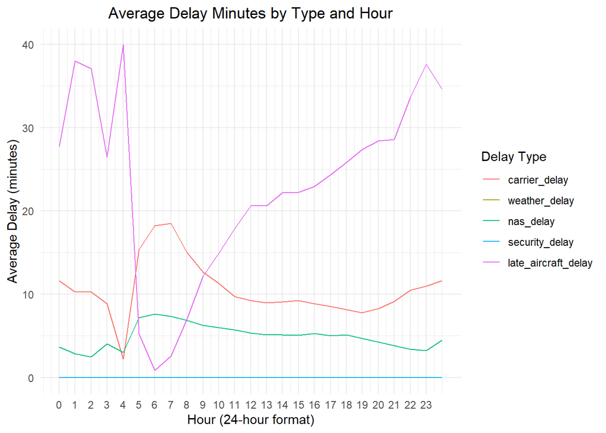

```r
delay_types <- hourly_stats %>%
  select(hour, carrier_delay, weather_delay, nas_delay,
         security_delay, late_aircraft_delay) %>%
  melt(id.vars = "hour")

ggplot(delay_types, aes(x = hour, y = value, color = variable)) +
  geom_line() +
  theme_minimal() +
  labs(title = "Average Delay Minutes by Type and Hour",
       x = "Hour (24-hour format)",
       y = "Average Delay (minutes)",
       color = "Delay Type") +
  scale_x_continuous(breaks = 0:23) +
  theme(plot.title = element_text(hjust = 0.5))
```

## 4.12 - Top 5 Airports Delay Analysis

This analysis is on patterns of hour-by-hour delays for the five busiest airports in the U.S., pinpointing times of the day when delays are more common. The code first identifies the top five airports with the most flights from the `flight_b` data set, then proceeds to calculate the average delay rate (percentage of flights delayed) and the average delay time (minutes) for each hour of the day for each of those airports.

The line chart below, from this analysis, visualizes the trends in how delay rates change by hour for each of these top airports, showing where peak delay times may be found and comparing trends across locations. Among the most compelling findings were that certain times of day—especially late afternoon and evening hours—tended to have higher delay rates, likely due to accumulated delays from earlier in the day or increased air traffic. Morning hours, on the other hand, typically have lower delay rates, probably due to fewer cumulative delays and a well-oiled operation.

This will be useful to the airport management and the airlines for hedging specific times that require extra resources or changes in operations. Knowing these patterns for high-traffic airports begs the opportunity to develop strategies—targeted, effective, and efficient—to reduce delays during peak hours and improve the level of service for travelers. Further exploration could include more variables, such as meteorological conditions or seasonal fluctuations, to better understand the causes of delays at these airports.

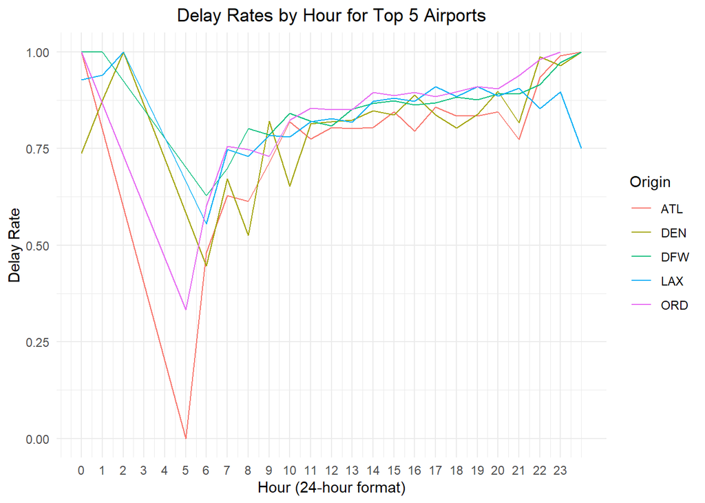

```r
top_airports <- flight_b %>%
  group_by(Origin) %>%
  summarise(total_flight = n()) %>%
  arrange(desc(total_flight)) %>%
  head(5)

airport_hourly <- flight_b %>%
  filter(Origin %in% top_airports$Origin) %>%
  group_by(Origin, hour) %>%
  summarise(
    delay_rate = mean(is_delayed, na.rm = TRUE),
    avg_delay = mean(Departure_Delay_min, na.rm = TRUE)
  )

ggplot(airport_hourly, aes(x = hour, y = delay_rate, color = Origin)) +
  geom_line() +
  theme_minimal() +
  labs(title = "Delay Rates by Hour for Top 5 Airports",
       x = "Hour (24-hour format)",
       y = "Delay Rate") +
  scale_x_continuous(breaks = 0:23) +
  theme(plot.title = element_text(hjust = 0.5))
```